# CPTR330 – Homework 7

Pierre Visconti

May 15, 2023

# K-means Algorithm

K-means is an unsupervised clustering algorithm. Since it is unsupervised so you do not need to tell the algorithm what labels look for and what to classify objects as. The goal of K-means is to give a label to an object based on the relationships present in the dataset, which is determined by the algorithm itself. K-means will aim to minimize the differences within clusters while maximizing the difference between the ‘k’ clusters. Some strengths of K-means is that it performs well for real world use cases and the algorithm itself is pretty basic which means it can be easily understood. Some weaknesses of K-means is that since it relies on some random chance you may get very different results for some datasets with each run. It also requires ‘k’ to be defined to run the algorithm which means that you must already have some idea of what the ‘k’ value should be.

## Step 1 - Collect Data

The source of the data is Shini, Renjith who captured user ratings from Google reviews. The dataset represents Google reviews on attractions from 24 categories across Europe.

## Step 2 - Exploring And Preparing The Data

importing the data

```r
data = read.csv("google_review_ratings.csv", header=TRUE)
colnames(data) = c("user_id", "churches", "resorts", "beaches", "parks", "theatres", "museums", "malls", "zoo", "restaurants", "bars", "local_services", "burger_pizza", "lodgings", "juice_bars", "art_galleries", "dance_clubs", "pools", "gyms", "bakeries", "spas", "cafes", "view_points", "monuments", "gardens")
```

The dataset has 26 features in total. One of which is the user id, and another which is included but was not specified on the UCI website as a feature. The rest are the 24 categories. We can eliminate the user id variable as it is not helpful.

```r
data = data[-1]
str(data)
```

```
## 'data.frame':    5456 obs. of  25 variables:
##  $ churches      : num  0 0 0 0 0 0 0 0 0 0 ...
##  $ resorts       : num  0 0 0 0.5 0 0 5 5 5 5 ...
##  $ beaches       : num  3.63 3.63 3.63 3.63 3.63 3.63 3.63 3.63 3.64 3.64 ...
##  $ parks         : num  3.65 3.65 3.63 3.63 3.63 3.63 3.63 3.63 3.64 3.64 ...
##  $ theatres      : num  5 5 5 5 5 5 5 5 5 5 ...
##  $ museums       : num  2.92 2.92 2.92 2.92 2.92 2.92 2.92 2.92 2.92 2.92 ...
##  $ malls         : num  5 5 5 5 5 5 3.03 5 3.03 5 ...
##  $ zoo           : num  2.35 2.64 2.64 2.35 2.64 2.63 2.35 2.63 2.62 2.35 ...
##  $ restaurants   : num  2.33 2.33 2.33 2.33 2.33 2.33 2.33 2.33 2.32 2.32 ...
##  $ bars          : num  2.64 2.65 2.64 2.64 2.64 2.65 2.64 2.64 2.63 2.63 ...
##  $ local_services: chr  "1.7" "1.7" "1.7" "1.73" ...
##  $ burger_pizza  : num  1.69 1.69 1.69 1.69 1.69 1.69 1.68 1.68 1.67 1.67 ...
##  $ lodgings      : num  1.7 1.7 1.7 1.7 1.7 1.69 1.69 1.69 1.68 1.67 ...
##  $ juice_bars    : num  1.72 1.72 1.72 1.72 1.72 1.72 1.71 1.71 1.7 1.7 ...
##  $ art_galleries : num  1.74 1.74 1.74 1.74 1.74 1.74 1.75 1.74 0.75 0.74 ...
##  $ dance_clubs   : num  0.59 0.59 0.59 0.59 0.59 0.59 0.59 0.6 0.6 0.59 ...
##  $ pools         : num  0.5 0.5 0.5 0.5 0.5 0.5 0.5 0.5 0 0 ...
##  $ gyms          : num  0 0 0 0 0 0 0 0 0 0 ...
##  $ bakeries      : num  0.5 0.5 0.5 0.5 0.5 0.5 0.5 0.5 0.5 0 ...
##  $ spas          : num  0 0 0 0 0 0 0 0 0 0 ...
##  $ cafes         : num  0 0 0 0 0 0 0 0 0 0 ...
##  $ view_points   : num  0 0 0 0 0 0 0 0 0 0 ...
##  $ monuments     : num  0 0 0 0 0 0 0 0 0 0 ...
##  $ gardens       : num  0 0 0 0 0 0 0 0 0 0 ...
##  $ NA            : num  NA NA NA NA NA NA NA NA NA NA ...
```

looking at data summary to check for ranges of each feature and converting category.11 to numerical

```r
data$local_services = as.numeric(data$local_services)
summary(data)
```

```
##     churches        resorts         beaches          parks
##  Min.   :0.000   Min.   :0.000   Min.   :0.000   Min.   :0.830
##  1st Qu.:0.920   1st Qu.:1.360   1st Qu.:1.540   1st Qu.:1.730
##  Median :1.340   Median :1.905   Median :2.060   Median :2.460
##  Mean   :1.456   Mean   :2.320   Mean   :2.489   Mean   :2.797
##  3rd Qu.:1.810   3rd Qu.:2.683   3rd Qu.:2.740   3rd Qu.:4.093
##  Max.   :5.000   Max.   :5.000   Max.   :5.000   Max.   :5.000
##
##     theatres        museums          malls            zoo
##  Min.   :1.120   Min.   :1.110   Min.   :1.120   Min.   :0.860
##  1st Qu.:1.770   1st Qu.:1.790   1st Qu.:1.930   1st Qu.:1.620
##  Median :2.670   Median :2.680   Median :3.230   Median :2.170
##  Mean   :2.959   Mean   :2.893   Mean   :3.351   Mean   :2.541
##  3rd Qu.:4.312   3rd Qu.:3.840   3rd Qu.:5.000   3rd Qu.:3.190
##  Max.   :5.000   Max.   :5.000   Max.   :5.000   Max.   :5.000
##
##   restaurants         bars       local_services  burger_pizza      lodgings
##  Min.   :0.840   Min.   :0.810   Min.   :0.78   Min.   :0.780   Min.   :0.770
##  1st Qu.:1.800   1st Qu.:1.640   1st Qu.:1.58   1st Qu.:1.290   1st Qu.:1.190
##  Median :2.800   Median :2.680   Median :2.00   Median :1.690   Median :1.610
##  Mean   :3.126   Mean   :2.833   Mean   :2.55   Mean   :2.078   Mean   :2.126
##  3rd Qu.:5.000   3rd Qu.:3.530   3rd Qu.:3.22   3rd Qu.:2.285   3rd Qu.:2.360
##  Max.   :5.000   Max.   :5.000   Max.   :5.00   Max.   :5.000   Max.   :5.000
##                                  NA's   :1      NA's   :1
##    juice_bars    art_galleries    dance_clubs        pools
##  Min.   :0.760   Min.   :0.000   Min.   :0.000   Min.   :0.0000
##  1st Qu.:1.030   1st Qu.:0.860   1st Qu.:0.690   1st Qu.:0.5800
##  Median :1.490   Median :1.330   Median :0.800   Median :0.7400
##  Mean   :2.191   Mean   :2.207   Mean   :1.193   Mean   :0.9492
##  3rd Qu.:2.740   3rd Qu.:4.440   3rd Qu.:1.160   3rd Qu.:0.9100
##  Max.   :5.000   Max.   :5.000   Max.   :5.000   Max.   :5.0000
##
##       gyms           bakeries           spas          cafes
##  Min.   :0.0000   Min.   :0.0000   Min.   :0.00   Min.   :0.0000
##  1st Qu.:0.5300   1st Qu.:0.5200   1st Qu.:0.54   1st Qu.:0.5700
##  Median :0.6900   Median :0.6900   Median :0.69   Median :0.7600
##  Mean   :0.8224   Mean   :0.9698   Mean   :1.00   Mean   :0.9658
##  3rd Qu.:0.8400   3rd Qu.:0.8600   3rd Qu.:0.86   3rd Qu.:1.0000
##  Max.   :5.0000   Max.   :5.0000   Max.   :5.00   Max.   :5.0000
##
##   view_points      monuments        gardens            NA
##  Min.   :0.000   Min.   :0.000   Min.   :0.000   Min.   :1.040
##  1st Qu.:0.740   1st Qu.:0.790   1st Qu.:0.880   1st Qu.:1.425
##  Median :1.030   Median :1.070   Median :1.290   Median :1.810
##  Mean   :1.751   Mean   :1.531   Mean   :1.561   Mean   :1.810
##  3rd Qu.:2.070   3rd Qu.:1.560   3rd Qu.:1.660   3rd Qu.:2.195
##  Max.   :5.000   Max.   :5.000   Max.   :5.000   Max.   :2.580
##                                  NA's   :1       NA's   :5454
```

As we can see all of the features are already normalized so we do not need to normalize the dataset. The only feature we need to deal with is X as it has a lot of NA values. We also have a single NA value for category.11, category.12 and category.24 which can be omitted.

Dealing with NA values for categories.

```r
# removing X feature since it only has 2 non NA values
data = data[-25]
# dealing with categories missing single observation
data = data[!is.na(data$local_services)&!is.na(data$burger_pizza)&!is.na(data$gardens),]
summary(data)
```

```
##     churches        resorts         beaches          parks
##  Min.   :0.000   Min.   :0.000   Min.   :0.000   Min.   :0.830
##  1st Qu.:0.920   1st Qu.:1.360   1st Qu.:1.540   1st Qu.:1.730
##  Median :1.340   Median :1.910   Median :2.060   Median :2.460
##  Mean   :1.456   Mean   :2.320   Mean   :2.489   Mean   :2.797
##  3rd Qu.:1.810   3rd Qu.:2.688   3rd Qu.:2.740   3rd Qu.:4.098
##  Max.   :5.000   Max.   :5.000   Max.   :5.000   Max.   :5.000
##     theatres        museums          malls            zoo
##  Min.   :1.120   Min.   :1.110   Min.   :1.120   Min.   :0.860
##  1st Qu.:1.770   1st Qu.:1.790   1st Qu.:1.930   1st Qu.:1.620
##  Median :2.670   Median :2.680   Median :3.230   Median :2.170
##  Mean   :2.959   Mean   :2.893   Mean   :3.351   Mean   :2.541
##  3rd Qu.:4.310   3rd Qu.:3.837   3rd Qu.:5.000   3rd Qu.:3.190
##  Max.   :5.000   Max.   :5.000   Max.   :5.000   Max.   :5.000
##   restaurants         bars       local_services   burger_pizza
##  Min.   :0.840   Min.   :0.810   Min.   :0.780   Min.   :0.780
##  1st Qu.:1.800   1st Qu.:1.640   1st Qu.:1.580   1st Qu.:1.290
##  Median :2.800   Median :2.680   Median :2.000   Median :1.690
##  Mean   :3.127   Mean   :2.833   Mean   :2.550   Mean   :2.078
##  3rd Qu.:5.000   3rd Qu.:3.527   3rd Qu.:3.217   3rd Qu.:2.288
##  Max.   :5.000   Max.   :5.000   Max.   :5.000   Max.   :5.000
##     lodgings       juice_bars   art_galleries    dance_clubs
##  Min.   :0.770   Min.   :0.76   Min.   :0.000   Min.   :0.000
##  1st Qu.:1.190   1st Qu.:1.03   1st Qu.:0.860   1st Qu.:0.690
##  Median :1.610   Median :1.49   Median :1.330   Median :0.800
##  Mean   :2.126   Mean   :2.19   Mean   :2.206   Mean   :1.193
##  3rd Qu.:2.360   3rd Qu.:2.74   3rd Qu.:4.440   3rd Qu.:1.160
##  Max.   :5.000   Max.   :5.00   Max.   :5.000   Max.   :5.000
##      pools             gyms           bakeries           spas
##  Min.   :0.0000   Min.   :0.0000   Min.   :0.0000   Min.   :0.0000
##  1st Qu.:0.5800   1st Qu.:0.5300   1st Qu.:0.5200   1st Qu.:0.5400
##  Median :0.7400   Median :0.6900   Median :0.6900   Median :0.6900
##  Mean   :0.9493   Mean   :0.8225   Mean   :0.9692   Mean   :0.9996
##  3rd Qu.:0.9100   3rd Qu.:0.8400   3rd Qu.:0.8600   3rd Qu.:0.8600
##  Max.   :5.0000   Max.   :5.0000   Max.   :5.0000   Max.   :5.0000
##      cafes         view_points      monuments        gardens
##  Min.   :0.0000   Min.   :0.000   Min.   :0.000   Min.   :0.000
##  1st Qu.:0.5700   1st Qu.:0.740   1st Qu.:0.790   1st Qu.:0.880
##  Median :0.7600   Median :1.030   Median :1.070   Median :1.290
##  Mean   :0.9653   Mean   :1.749   Mean   :1.531   Mean   :1.561
##  3rd Qu.:1.0000   3rd Qu.:2.070   3rd Qu.:1.560   3rd Qu.:1.660
##  Max.   :5.0000   Max.   :5.000   Max.   :5.000   Max.   :5.000
```

As we can see, all the NA values have been dealt with.

Checking for outliers

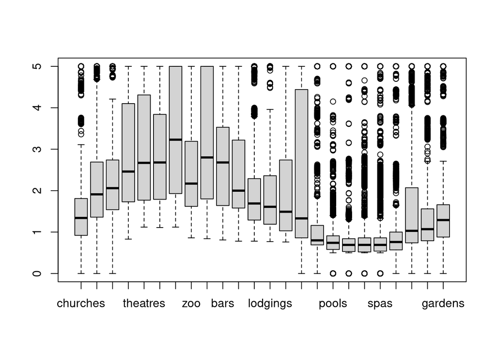

```r
boxplot(data)
```

## Step 3 - Training A Model On The Data

We train and create the model using the kmeans() function from the R stats library. The kmeans() function takes in a dataset as a paramater along with a ‘k’ value which specifies the desired number of clusters.

training model with 3 clusters

```r
set.seed(330)
clusters = kmeans(data, 3)
```

## Step 4 - Evaluating Model Performance

To check model performance, we must manually inspect the clusters and see if the model is producing any noticeable relationships.

```r
clusters$size
```

```
## [1] 1898 2456 1100
```

```r
clusters$centers
```

```
##   churches  resorts  beaches    parks theatres  museums    malls      zoo
## 1 1.469041 2.574052 3.169974 3.935084 4.366596 3.693583 3.397592 2.397761
## 2 1.091588 1.940639 1.916450 2.100521 2.254410 2.710423 3.918893 3.080297
## 3 2.245873 2.728891 2.592655 2.388845 2.102936 1.921373 2.005018 1.584927
##   restaurants     bars local_services burger_pizza lodgings juice_bars
## 1    2.667455 2.576886       2.312555     1.931270 1.898804   1.453309
## 2    4.021474 3.574243       3.182203     2.490216 2.581156   2.923787
## 3    1.920536 1.618409       1.546291     1.412800 1.500882   1.824909
##   art_galleries dance_clubs     pools      gyms  bakeries      spas     cafes
## 1      1.277682    1.089189 0.7182139 0.5370021 0.5621707 0.6738198 0.8305479
## 2      2.870594    1.057887 0.7658347 0.6083998 0.7029397 0.7316450 0.6971173
## 3      2.324609    1.672355 1.7579000 1.7932636 2.2662455 2.1601182 1.7964636
##   view_points monuments  gardens
## 1   2.1630875 1.8694784 1.698330
## 2   0.9948412 0.9029194 1.059805
## 3   2.7200545 2.3495545 2.440945
```

It is hard to tell whether the model is producing meaningful clusters are actually different from each other or not. The clusters have similar values for many of the features yet there are some features like theatres, museums, malls, restaurants, and spas that have very different mean ratings across the clusters. If we focus on these features we realize that there are some differences between the clusters so the model does seem to be producing some good results.

## Step 5 - Improving Model Performance

To improve the model we can use our results to get insight on the dataset and turn these insights into action. We can also tune the ‘k’ value to change the number of clusters.

Examining cluster assignment to individual characteristics

```r
# apply the cluster IDs to the original data frame
data$cluster <- clusters$cluster
# look at the first five records for the features we noticed a difference in
data[1:5, c("theatres", "museums", "malls")]
```

|  | theatres | museums | malls |
| --- | --- | --- | --- |
| 1 | 5 | 2.92 | 5 |
| 2 | 5 | 2.92 | 5 |
| 3 | 5 | 2.92 | 5 |
| 4 | 5 | 2.92 | 5 |
| 5 | 5 | 2.92 | 5 |

```r
# mean age by cluster
aggregate(data = data, theatres ~ cluster, mean)
```

| cluster | theatres |
| --- | --- |
| 1 | 4.366596 |
| 2 | 2.254410 |
| 3 | 2.102936 |

```r
# proportion of females by cluster
aggregate(data = data, museums ~ cluster, mean)
```

| cluster | museums |
| --- | --- |
| 1 | 3.693583 |
| 2 | 2.710423 |
| 3 | 1.921373 |

```r
# mean number of friends by cluster
aggregate(data = data, malls ~ cluster, mean)
```

| cluster | malls |
| --- | --- |
| 1 | 3.397592 |
| 2 | 3.918893 |
| 3 | 2.005018 |

Creating a model with 5 clusters

```r
set.seed(330)
clusters = kmeans(data, 5)
clusters$size
```

```
## [1] 1607 1226  714  984  923
```

```r
clusters$centers
```

```
##    churches  resorts  beaches    parks theatres  museums    malls      zoo
## 1 1.3444866 2.815314 3.009203 3.477218 4.115607 3.842595 3.877212 2.510560
## 2 1.1769086 1.988148 1.776591 2.059282 2.187088 2.730808 4.024739 3.727847
## 3 1.6266387 2.166807 3.095028 4.325252 4.123123 3.213894 2.739062 2.226373
## 4 2.3334045 2.759675 2.562642 2.290508 2.080854 1.903943 1.957154 1.551138
## 5 0.9519718 1.548472 1.982611 1.950964 2.005677 2.263824 3.502069 2.317248
##   restaurants     bars local_services burger_pizza lodgings juice_bars
## 1    2.928513 2.417424       2.086136     2.051612 1.973566   1.872290
## 2    4.640155 4.386623       3.589592     1.993328 1.746982   1.576313
## 3    2.691667 2.764608       2.760182     1.632801 1.901064   1.260140
## 4    1.820234 1.552236       1.527764     1.403100 1.500224   1.798059
## 5    3.189870 2.909415       2.901723     3.302676 3.734908   4.697985
##   art_galleries dance_clubs     pools      gyms  bakeries      spas     cafes
## 1      1.540765    1.030821 0.6626820 0.5207903 0.5768388 0.6880025 0.7652458
## 2      2.092667    1.011917 0.6478140 0.4561338 0.4680016 0.5627243 0.6609625
## 3      1.168095    1.196513 0.8757003 0.6725770 0.6143557 0.8860224 1.0130812
## 4      2.265732    1.542612 1.6694106 1.7768394 2.4755386 2.2186687 1.8388618
## 5      4.254789    1.338743 1.1382990 0.9331419 0.9869556 0.9107801 0.7494475
##   view_points monuments   gardens  cluster
## 1   0.8480896 1.3831487 1.5639515 1.235843
## 2   1.1042007 1.0064192 1.1117700 1.984502
## 3   4.7580672 2.5281232 1.7751120 1.187675
## 4   2.6782012 2.4024695 2.5561992 3.000000
## 5   0.8577356 0.7851029 0.9234236 2.048754
```

The differences between clusters appears to be more drastic with thenumber of clusters set to 5 instead of 3, which indicates that 3 clusters was probably too low for this dataset.

## Autograding

```r
#.AutograderMyTotalScore()
```